# s670-HW2

Ruchik Rohit Dama

### Loading the Data

Using read.delim to load the txt file into table format.

```r
vehicles = read.delim(file = "vehicles.txt", header = TRUE, sep = "", dec = ".")
```

### Question 1:- By transforming the data to “wide form” or otherwise, estimate the mean number of vehiclesowned per household for each county in the data set. Plot the distribution of this variable.

Converting the data into wide format using pivot_wider.

```r
 vehicles_wide=vehicles %>%
pivot_wider(names_from = variable, values_from = c(estimate, moe))
vehicles_wide
```

```
## # A tibble: 3,220 x 16
##    GEOID NAME        estimate_total estimate_cars0 estimate_cars1 estimate_cars2
##    <int> <chr>                <int>          <int>          <int>          <int>
##  1  1001 Autauga Co~          21397            941           6745           7829
##  2  1003 Baldwin Co~          80930           2656          26040          34844
##  3  1005 Barbour Co~           9345            950           3426           3017
##  4  1007 Bibb Count~           6891            425           2121           2570
##  5  1009 Blount Cou~          20847            860           5429           7346
##  6  1011 Bullock Co~           3521            377           1077           1101
##  7  1013 Butler Cou~           6506            488           2133           2157
##  8  1015 Calhoun Co~          44605           2659          13546          16817
##  9  1017 Chambers C~          13448            980           4210           4602
## 10  1019 Cherokee C~          10737            480           2879           4072
## # ... with 3,210 more rows, and 10 more variables: estimate_cars3 <int>,
## #   estimate_cars4 <int>, estimate_median_income <int>, moe_total <int>,
## #   moe_cars0 <int>, moe_cars1 <int>, moe_cars2 <int>, moe_cars3 <int>,
## #   moe_cars4 <int>, moe_median_income <int>
```

Calculating the mean number of vehicles per household

```r
vehicles_wide$mean_vehicles=((vehicles_wide$estimate_cars1+vehicles_wide$estimate_cars2*2+vehicles_wide$estimate_cars3*3+vehicles_wide$estimate_cars4*4)/(vehicles_wide$estimate_cars0+vehicles_wide$estimate_cars1+vehicles_wide$estimate_cars2+vehicles_wide$estimate_cars3+vehicles_wide$estimate_cars4))

vehicles_wide
```

```
## # A tibble: 3,220 x 17
##    GEOID NAME        estimate_total estimate_cars0 estimate_cars1 estimate_cars2
##    <int> <chr>                <int>          <int>          <int>          <int>
##  1  1001 Autauga Co~          21397            941           6745           7829
##  2  1003 Baldwin Co~          80930           2656          26040          34844
##  3  1005 Barbour Co~           9345            950           3426           3017
##  4  1007 Bibb Count~           6891            425           2121           2570
##  5  1009 Blount Cou~          20847            860           5429           7346
##  6  1011 Bullock Co~           3521            377           1077           1101
##  7  1013 Butler Cou~           6506            488           2133           2157
##  8  1015 Calhoun Co~          44605           2659          13546          16817
##  9  1017 Chambers C~          13448            980           4210           4602
## 10  1019 Cherokee C~          10737            480           2879           4072
## # ... with 3,210 more rows, and 11 more variables: estimate_cars3 <int>,
## #   estimate_cars4 <int>, estimate_median_income <int>, moe_total <int>,
## #   moe_cars0 <int>, moe_cars1 <int>, moe_cars2 <int>, moe_cars3 <int>,
## #   moe_cars4 <int>, moe_median_income <int>, mean_vehicles <dbl>
```

Distribution of mean_vehicles

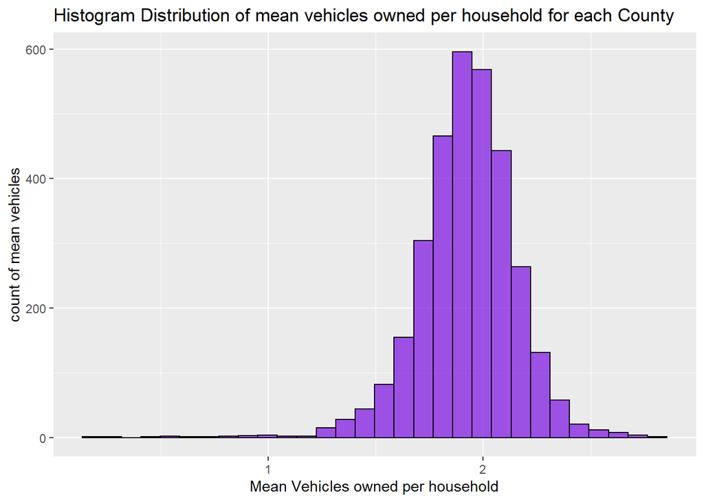

```r
ggplot(data=vehicles_wide, aes(x=mean_vehicles)) +geom_histogram(alpha=0.8,position="identity",fill="#8A2BE2",color="black")+
  xlab("Mean Vehicles owned per household") +
  ylab("count of mean vehicles")+
  ggtitle("Histogram Distribution of mean vehicles owned per household for each County" )
```

### Question 2:- Plot vehicles owned (y-axis) against median income (x-axis) for each county. Add the linearregression line. How well does the line fit?

Calculating total number of cars owned

```r
vehicles_wide$'total_vehicles'= (vehicles_wide$estimate_cars1+vehicles_wide$estimate_cars2*2+vehicles_wide$estimate_cars3*3+vehicles_wide$estimate_cars4*4)
vehicles_wide
```

```
## # A tibble: 3,220 x 18
##    GEOID NAME        estimate_total estimate_cars0 estimate_cars1 estimate_cars2
##    <int> <chr>                <int>          <int>          <int>          <int>
##  1  1001 Autauga Co~          21397            941           6745           7829
##  2  1003 Baldwin Co~          80930           2656          26040          34844
##  3  1005 Barbour Co~           9345            950           3426           3017
##  4  1007 Bibb Count~           6891            425           2121           2570
##  5  1009 Blount Cou~          20847            860           5429           7346
##  6  1011 Bullock Co~           3521            377           1077           1101
##  7  1013 Butler Cou~           6506            488           2133           2157
##  8  1015 Calhoun Co~          44605           2659          13546          16817
##  9  1017 Chambers C~          13448            980           4210           4602
## 10  1019 Cherokee C~          10737            480           2879           4072
## # ... with 3,210 more rows, and 12 more variables: estimate_cars3 <int>,
## #   estimate_cars4 <int>, estimate_median_income <int>, moe_total <int>,
## #   moe_cars0 <int>, moe_cars1 <int>, moe_cars2 <int>, moe_cars3 <int>,
## #   moe_cars4 <int>, moe_median_income <int>, mean_vehicles <dbl>,
## #   total_vehicles <dbl>
```

Plotting scatterplot for median_income v/s mean vehicles owned per household for each county.

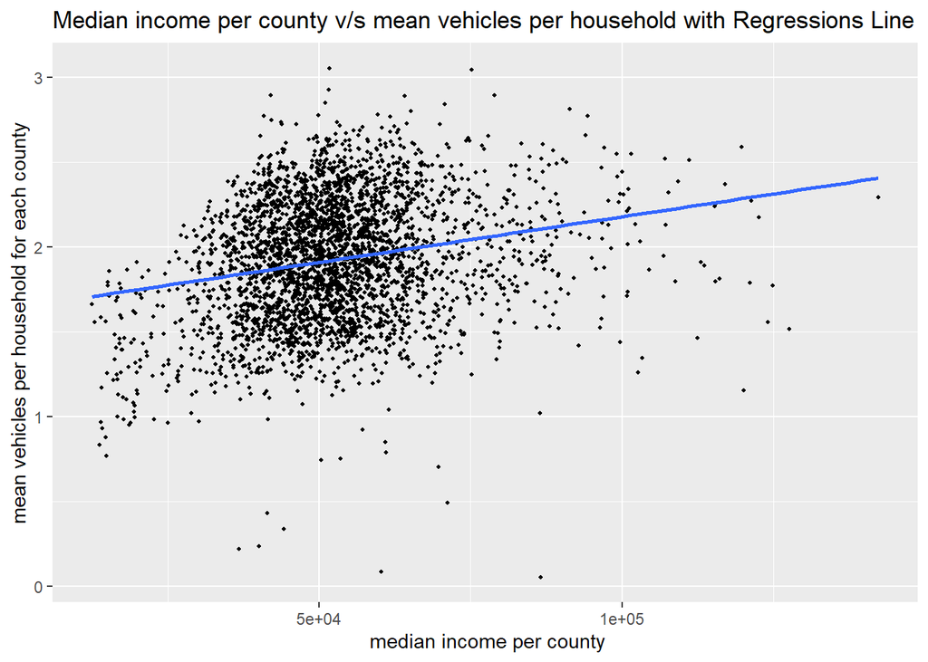

```r
gg_total_median =ggplot(vehicles_wide,aes(x = estimate_median_income, y = mean_vehicles))+geom_jitter(height = 0.5, width = 0.5, size = 0.7)+labs(title = "Median income per county v/s mean vehicles per household with Regressions Line",x=" median income per county",y="mean vehicles per household for each county")+ stat_smooth(method='lm', se = FALSE)
gg_total_median
```

#### The data points are spread across the whole graph but the majority of the points are concentrated near median income of 50,000 and 60,000. The regression line does not seems to be a decent fit on the graph.

### QUestion 3:- Plot vehicles owned against median income using a log scale on thex-axis for each county.Add the linear regression line. Does this line fit any better?

Plotting scatterplot for log of the median_income v/s mean vehicles owned per household for each county.

[figure not shown]

```r
gg_total_median_log =ggplot(vehicles_wide,aes(x = estimate_median_income, y = mean_vehicles))+geom_jitter(height = 0.25, width = 0.5, size = 0.7)+scale_x_log10()+labs(title = "Log of Median income per county v/s mean vehicles per household with Regressions Line",x="Log of median income",y="mean vehicles per household for each county")+  geom_smooth(method='lm')
gg_total_median_log
```

#### The above graph is plotted between log of the median income and mean vehicles owned per household for each county. The data points are more spread out on the graph than the data points of median income v/s mean vehicles owned per household graph. So, the regression line does seems to be a good fit for the above graph. So, using the log of the median income seems to be better than the median income.

### Question 4:- Fit a linear regression that predicts vehicles owned using median income for each county. Listthe ten counties with the lowest (most negative) residuals. Do these seem like the easiestplaces to live without a car?

#### So, first used lm() to fit a linear model that predicts mean vehicles owned per household for each county using median income. Then added a residual column in my table and arranged the table in ascending order with respect to the residual column and then listing the top 10 counties with lowest residuals.

```r
vehicles_wide_df=lm(mean_vehicles~estimate_median_income,data=vehicles_wide)
vehicles_wide_df=augment(vehicles_wide_df)
vehicles_wide$residual=vehicles_wide_df$.resid
vehicles_wide_residual=vehicles_wide %>% arrange(vehicles_wide$residual)
vehicles_wide_residual$cars0_per=(vehicles_wide_residual$estimate_cars0/vehicles_wide_residual$estimate_total)*100
vehicles_wide_residual$NAME[1:10]
```

```
##  [1] "New York County, New York"
##  [2] "Kusilvak Census Area, Alaska"
##  [3] "Northwest Arctic Borough, Alaska"
##  [4] "Kings County, New York"
##  [5] "Bronx County, New York"
##  [6] "Nome Census Area, Alaska"
##  [7] "Bethel Census Area, Alaska"
##  [8] "District of Columbia, District of Columbia"
##  [9] "North Slope Borough, Alaska"
## [10] "San Francisco County, California"
```

```r
vehicles_wide_cars0_per=vehicles_wide_residual[order(vehicles_wide_residual$cars0_per,decreasing = TRUE),]
(vehicles_wide_cars0_per$NAME[1:10])
```

```
##  [1] "Kusilvak Census Area, Alaska"       "New York County, New York"
##  [3] "Northwest Arctic Borough, Alaska"   "Bronx County, New York"
##  [5] "Nome Census Area, Alaska"           "Bethel Census Area, Alaska"
##  [7] "Kings County, New York"             "Yukon-Koyukuk Census Area, Alaska"
##  [9] "Lake and Peninsula Borough, Alaska" "North Slope Borough, Alaska"
```

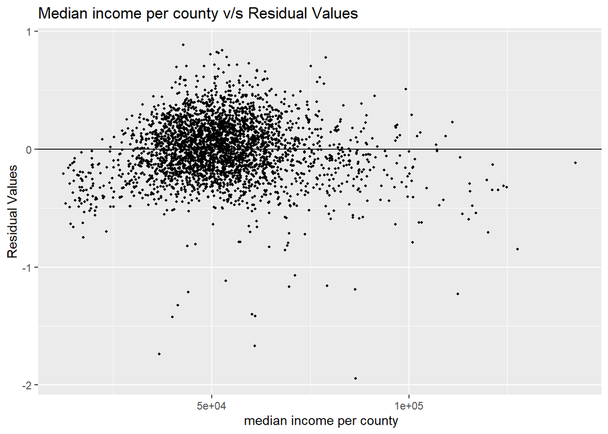

```r
ggplot(vehicles_wide_residual,aes(x = estimate_median_income, y = residual))+geom_jitter(height = 0.25, width = 0.5, size = 0.7)+labs(title = "Median income per county v/s Residual Values",x=" median income per county",y="Residual Values")+geom_abline(slope=0)
```

#### while looking at the residual plot of median income v/s residual, we can see that the data points are concentrated between 40,000 to 60,000, but the residual plots should be more scatteresd around zero.

### Question 5:- Fit a linear regression that predicts vehicles owned using log median income for each county.List the ten counties with the lowest (most negative) residuals. Do these seem any more likethe easiest places to live without a car?

```r
vehicles_wide$median_log=(log(vehicles_wide$estimate_median_income))
vehicles_wide_df=lm(mean_vehicles~median_log,data=vehicles_wide)
vehicles_wide_df=augment(vehicles_wide_df)
vehicles_wide$residual_log=vehicles_wide_df$.resid
vehicles_wide_residual_log=vehicles_wide[order(vehicles_wide$residual),]
vehicles_wide_residual_log$cars0_per=(vehicles_wide_residual_log$estimate_cars0/vehicles_wide_residual_log$estimate_total)*100
vehicles_wide_residual_log$NAME[1:10]
```

```
##  [1] "New York County, New York"
##  [2] "Kusilvak Census Area, Alaska"
##  [3] "Northwest Arctic Borough, Alaska"
##  [4] "Kings County, New York"
##  [5] "Bronx County, New York"
##  [6] "Nome Census Area, Alaska"
##  [7] "Bethel Census Area, Alaska"
##  [8] "District of Columbia, District of Columbia"
##  [9] "North Slope Borough, Alaska"
## [10] "San Francisco County, California"
```

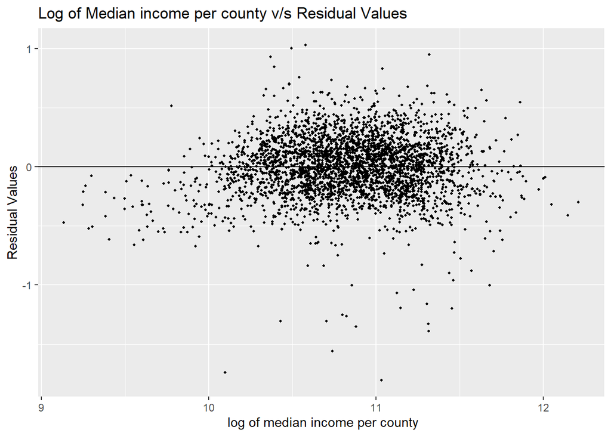

```r
ggplot(vehicles_wide_residual_log,aes(x = median_log, y = residual))+geom_jitter(height = 0.25, width = 0.5, size = 0.7)+labs(title = "Log of Median income per county v/s Residual Values",x=" log of median income per county",y="Residual Values")+geom_abline(slope=0)
```